# Mixed Models

Sean M. Lee

# The phonetic profile of Korean formal and informal speech registers (Winter & Grawunder 2012)

Summary: The authors sought to determine whether there were differences in pitch when Koreans spoke formally and informally. They found that Koreans spoke in a lower pitch when speaking formally.

The authors used mixed modeling to test this, and I will explain why mixed models are necessary for this type of study.

## Read in the data:

```r
winter <- read.table(file = "http://hompal-stats.wabarr.com/datasets/winter_korean.txt", header = T, sep = "\t")
head(winter)
```

```
##   subject gender scenario attitude frequency
## 1      F1      F        1      pol     213.3
## 2      F1      F        1      inf     204.5
## 3      F1      F        2      pol     285.1
## 4      F1      F        2      inf     259.7
## 5      F1      F        3      pol     203.9
## 6      F1      F        3      inf     286.9
```

## Note the variables used:

**Subject** *(F1, F2, M1, etc.)*

**Gender** *(Male or Female)*

**Scenario** *(7 different scenarios)*

**Attitude** *(Formal or Informal)*

**Frequency** *(in Hertz)*

### If you did this study without considering random effects, you could make a simple linear model comprised of only *Fixed Factors*:

##### frequency ~ attitude + gender + random error

### But notice how this is only 3 of the 5 variables listed above. That’s because there are two additional factors that are not fixed: Subject and Scenario

**Scenario** is a random factor because there are theoretically infinite types of scenarios, only 7 of which were included in this study. Therefore, the 7 levels of scenario represent a subset drawn from a potentially REALLY large number of scenarios. Each scenario may have a unique thing about it that causes any subject in that scenario to act in a slightly similar way, and this may differ from other scenarios. Since we don’t know how all the possible types of scenarios differ from each other, we must treat it as a *random effect*. This is in contrast to a *fixed effect*, like sex, in which we have a good idea of how males and females differ.

**Subject** is a random factor because multiple measurements were recorded for each individual subject, or in other words, *repeated measures* were taken. Just like how scenarios may differ from each other, each subject may have something unique about it that causes it to respond to each scenario in a slightly different way than other subjects. This is why mixed models are often used in behavioral studies like primatology–you’re often taking multiple measurements on the same, known individuals.

## You can visualize this by boxplotting each random factor:

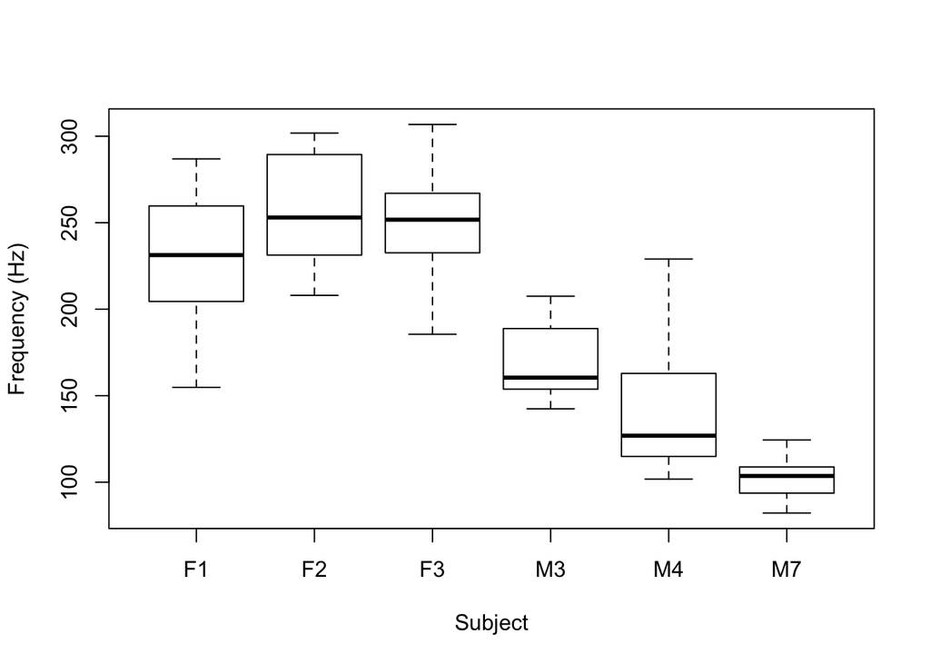

**Notice how for each subject you have a different median and variance. Since we don’t know how F137 or M982 or any other subject not included in this study differs in this regard, we have to treat this variance as a random effect. This differs from the following Male vs Female boxplot because we know there aren’t any more types of sexes (well, at least as far as this study is concerned).**

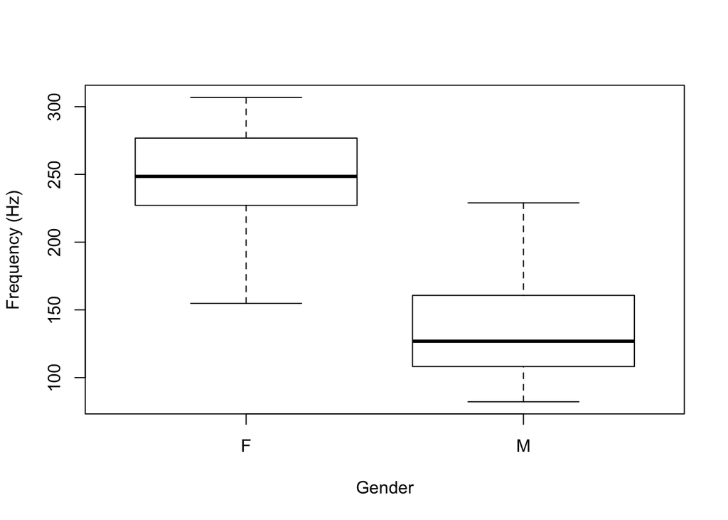

**That’s it–just male and female and nothing else.**

**And, to beat this idea in, as with subject, each scenario exhibits its own variation:**

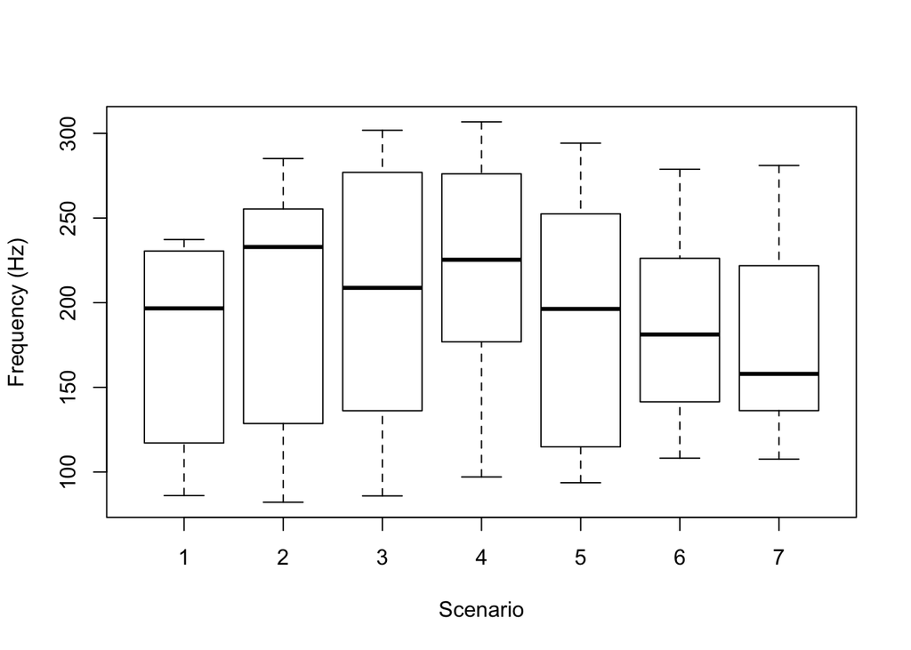

## Okay, okay, so how do you include random effects in a linear model? Well, the theoretical formula looks like this:

##### frequency ~ attitude + gender + (1 | subject) + (1 | scenario) + remaining random error

*Note: Random effects are indicated as (1 | randomeffect)*

## But how do you do this in R goddammit? Fortunately, it’s pretty much the same as the theoretical formula above.

## But first, install the lme4 package and load it up:

```r
library(lme4)
```

## Then you can try it out:

```r
my.model <- lmer(formula = frequency ~ attitude + gender + (1 | subject) + (1 | scenario), data = winter)
my.model
```

```
## Linear mixed model fit by REML ['lmerMod']
## Formula: frequency ~ attitude + gender + (1 | subject) + (1 | scenario)
##    Data: winter
## REML criterion at convergence: 775.4547
## Random effects:
##  Groups   Name        Std.Dev.
##  scenario (Intercept) 14.81
##  subject  (Intercept) 24.81
##  Residual             25.41
## Number of obs: 83, groups:  scenario, 7; subject, 6
## Fixed Effects:
## (Intercept)  attitudepol      genderM
##      256.85       -19.72      -108.52
```

## This tells you a bunch of stuff, but let’s look closer at the summary:

```r
summary(my.model)
```

```
## Linear mixed model fit by REML ['lmerMod']
## Formula: frequency ~ attitude + gender + (1 | subject) + (1 | scenario)
##    Data: winter
##
## REML criterion at convergence: 775.5
##
## Scaled residuals:
##     Min      1Q  Median      3Q     Max
## -2.2591 -0.6236 -0.0772  0.5388  3.4795
##
## Random effects:
##  Groups   Name        Variance Std.Dev.
##  scenario (Intercept) 219.5    14.81
##  subject  (Intercept) 615.6    24.81
##  Residual             645.9    25.41
## Number of obs: 83, groups:  scenario, 7; subject, 6
##
## Fixed effects:
##             Estimate Std. Error t value
## (Intercept)  256.846     16.116  15.938
## attitudepol  -19.721      5.584  -3.532
## genderM     -108.516     21.013  -5.164
##
## Correlation of Fixed Effects:
##             (Intr) atttdp
## attitudepol -0.173
## genderM     -0.652  0.004
```

## Notice how there are no p-values.

**This is because p-values are calculated differently for mixed models. There are various ways to do this, but the *Likelihood Ratio Test* is pretty common and simple.**

## Likelihood Ratio Test

**Step 1: Make the same mixed model without the factor of interest (attitude) and this is your null model.**

**Step 2: Compare it to the model we just created (with factor of interest included) using ANOVA.**

#### NULL MODEL = Mixed Model WITHOUT factor of interest (which is attitude, because we’re trying to see how formal/informal influences pitch)

```r
my.nullmodel = lmer(formula = frequency ~ gender + (1 | subject) + (1 | scenario), data = winter, REML = FALSE)
```

(You must do REML = FALSE. I’m not really sure what this does, something about a Likelihood Estimator, but anyway for Likelihood Ratio Test you have to do this. See Pinheiro & Bates, 2000; Bolker et al., 2009)

#### ALTERNATIVE MODEL = Mixed Model WITH factor of interest (note that this is the same model we made earlier, but you have to include the REML thingy)

```r
my.model <- lmer(formula = frequency ~ attitude + gender + (1 | subject) + (1 | scenario),  data = winter, REML = FALSE)
```

#### ANOVA

```r
anova(my.nullmodel, my.model)
```

```
## Data: winter
## Models:
## my.nullmodel: frequency ~ gender + (1 | subject) + (1 | scenario)
## my.model: frequency ~ attitude + gender + (1 | subject) + (1 | scenario)
##              Df    AIC    BIC  logLik deviance  Chisq Chi Df Pr(>Chisq)
## my.nullmodel  5 816.72 828.81 -403.36   806.72
## my.model      6 807.10 821.61 -397.55   795.10 11.618      1  0.0006532
##
## my.nullmodel
## my.model     ***
## ---
## Signif. codes:  0 '***' 0.001 '**' 0.01 '*' 0.05 '.' 0.1 ' ' 1
```